# Ch3: Introduction to linear regression

2014年11月26日

## Outline

- Introduction to linear regression
  - Model definition
  - Least Square Estimator and its property
  - Evaluation of our model: R-squared
  - Interaction: Simpson's paradox, Hierarchical principal
- Trouble shooting
  - Non linearity
  - Correlation of error terms
  - Non-constant variance of error terms
  - Outliers and Leverage
  - Collinearity

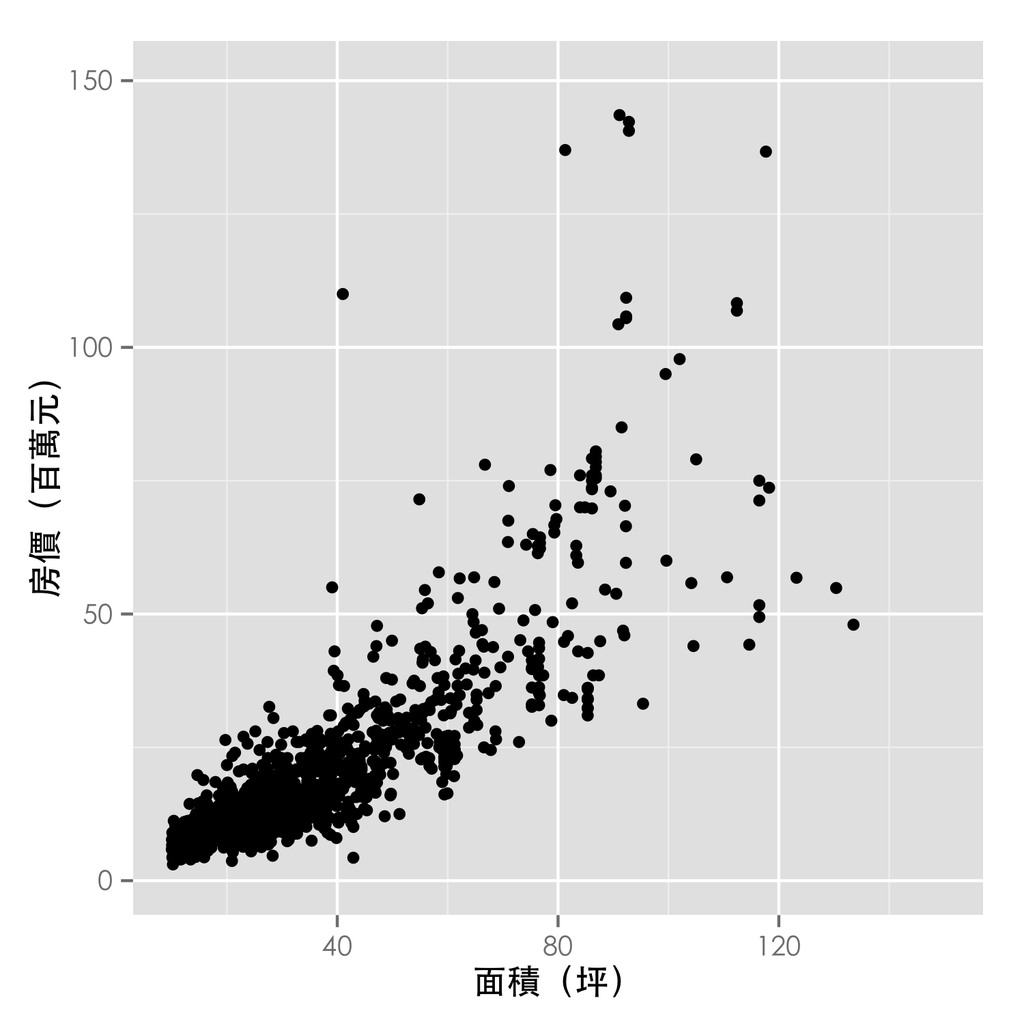

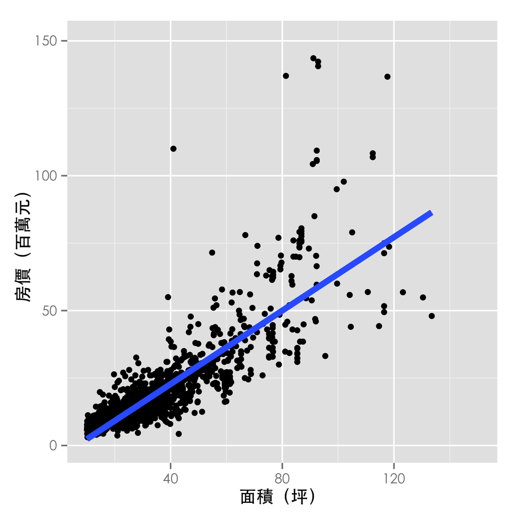

## Model definition

Linear regression is a statistical tool assumes that the dependence of \(y\) is linear on \(\boldsymbol{X}_1, \boldsymbol{X}_2, ..., \boldsymbol{X}_p\). \[ \boldsymbol{Y} = \beta_0 + \beta_1\boldsymbol{X_1} + \beta_2\boldsymbol{X_2} + \epsilon \text{ } \rightarrow \text{ } \boldsymbol{Y} = \boldsymbol{X}\boldsymbol{\beta} + \boldsymbol{\epsilon} \]

- When to use linear regression?
  - causal relationship
  - association
- Why develop the fitted line?
  - description (\(\hat{\beta}\))
  - prediction (\(\hat{y}\))

## Ordinary Least Square Estimator

How to find the best fitted line?

[figure not shown]

[ref](http://chemwiki.ucdavis.edu/Analytical_Chemistry/Analytical_Chemistry_2.0/05_Standardizing_Analytical_Methods/5D%3A_Linear_Regression_and_Calibration_Curves)

## Ordinary Least Square Estimator

[figure not shown]

\[\hat{\boldsymbol{\beta}} = arg{min{\sum{(y_i - \hat{y_i})^2}}}\]

## Ordinary Least Square Estimator

Geometric interpretation

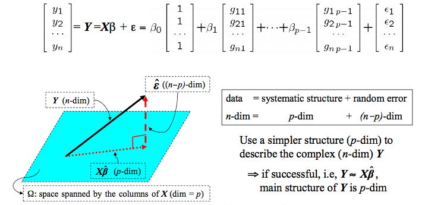

\[ \boldsymbol{X\hat{\beta}} = \boldsymbol{X(X^TX)^{-1}X^TY} \]

## Maximum Likelihood Estimator

- How to get MLE
- Assumptions we need in MLE, that is \(\boldsymbol{\epsilon} \sim N(\boldsymbol{0},\sigma^2\boldsymbol{I})\)
- Consistency and most efficiency

## Best Linear Unbiased Estimator

### Gauss-Markov theorem:

Let \(\boldsymbol{\beta}\) as the OLS estimator.  
If \(E(\epsilon) = \boldsymbol{0}\) and \(Var(\epsilon)=\sigma^2\boldsymbol{I}\), then \(\boldsymbol{\beta}\) is BLUE.

- BLUE [ref](http://en.wikipedia.org/wiki/Gauss%E2%80%93Markov_theorem)

## Remark

- More covariate leads to higher R-square
- Would be large for model without intercept [ref](http://www.ats.ucla.edu/stat/mult_pkg/faq/general/noconstant.htm)
- Cannot determine whether the coefficient estimates and predictions are biased
- Canont detecte nonlinearity [ref](http://blog.minitab.com/blog/adventures-in-statistics/regression-analysis-how-do-i-interpret-r-squared-and-assess-the-goodness-of-fit)

## Interaction

- Simpson's paradox [ref](http://vudlab.com/simpsons/)
- Interaction [ref](https://onlinecourses.science.psu.edu/stat501/node/74)
- Hierarchical principal (Why main effect should be included if the interaction is significant, see ISLR book)

## Nonlinearity

[figure not shown]

## Nonlinearity

### Solutions

- Polynomial regression [ref](http://en.wikipedia.org/wiki/Polynomial_regression)
- Local regression [ref](http://en.wikipedia.org/wiki/Local_regression)
- Kernel smoother [ref](http://en.wikipedia.org/wiki/Kernel_smoother)
- Smoothing spline [ref](http://en.wikipedia.org/wiki/Smoothing_spline)

## Bone Mineral Density

美國青少年脊柱骨質密度相對成長資料  
資料來源：Bachrach et al. (1999)

```r
library(ElemStatLearn)
data(bone) # BMD of 261 north american adolescents
bone[sample(nrow(bone), 8),]
```

```
##     idnum   age gender    spnbmd
## 419   298 24.50   male -0.014260
## 238   121 11.15 female  0.030059
## 438   314 20.10 female -0.006263
## 365   240 12.70   male  0.044097
## 313   182 24.70   male  0.002915
## 211   106 18.70   male  0.007150
## 271   149 14.25 female  0.014477
## 178    90 19.55 female  0.000000
```

## Bone Mineral Density

美國青少年脊柱骨質密度相對成長資料  
觀察年齡與骨質密度相對成長之散佈圖

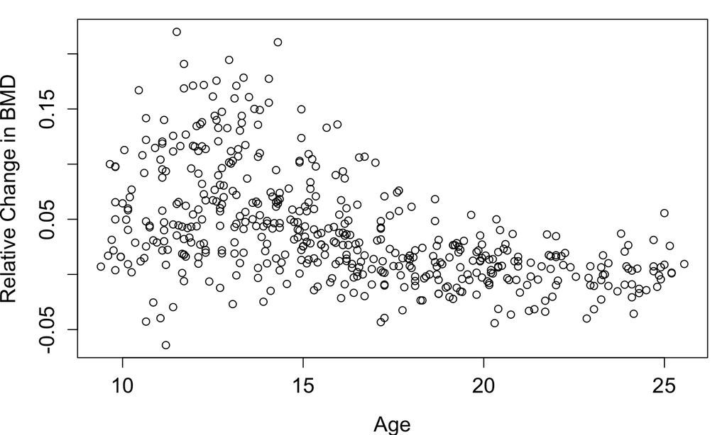

## Bone Mineral Density

美國青少年脊柱骨質密度相對成長資料  
觀察年齡與骨質密度相對成長之散佈圖

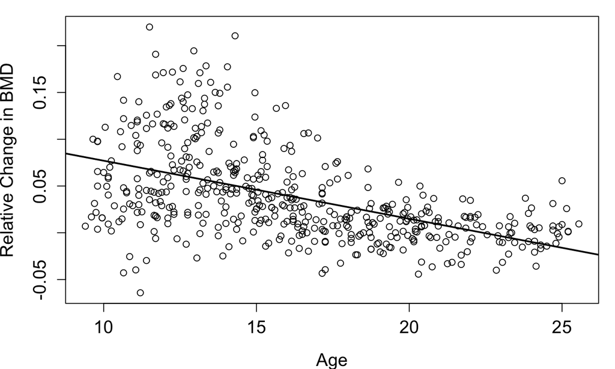

## Bone Mineral Density

美國青少年脊柱骨質密度相對成長資料  
以性別分組，觀察年齡與骨質密度相對成長之散佈圖

[figure not shown]

## Bone Mineral Density

美國青少年脊柱骨質密度相對成長資料  
利用平滑曲線法 (smooth splines) 觀察不同性別之趨勢

[figure not shown]

## Bone Mineral Density

```r
# 骨質密度成長率 vs 年齡
plot(spnbmd ~ age, data=bone, xlab="Age", ylab="Relative Change in BMD")
abline(lm(spnbmd ~ age, data=bone), lwd=2)

# 以性別分層
plot(spnbmd ~ age, data=bone, col = ifelse(gender=="male", 4, 2),
     xlab="Age", ylab="Relative Change in BMD")
legend("topright", c("male", "Female"), col=c(4, 2),
       pch=1, bty="n", cex=1.2)
```

## Bone Mineral Density

```r
# 平滑曲線分析
sp.male <- with(subset(bone,gender=="male"),
                smooth.spline(age, spnbmd, df=12))
sp.female <- with(subset(bone, gender=="female"),
                  smooth.spline(age, spnbmd, df=12))
plot(spnbmd ~ age, data=bone, col = ifelse(gender=="male", 4, 2),
     xlab="Age", ylab="Relative Change in BMD", pch=1)
lines(sp.male, col=4, lwd=5)
lines(sp.female, col=2, lwd=5)
legend("topright", legend=c("male", "Female"), col=c(4, 2),
       lwd=2, bty="n", cex=1.2)
```

## Important issue

- Non-constant variance of error terms
- Time depedent data
- Outliers and leverage
- Normality of variance

## Residual Analysis

- Residual vs. Independent
  - Checking the error variance
  - Improving the regression model
- Residual vs. Predicted Value
- Residual vs. Order of the Data
  - Checking the error variance, drift
  - Time series
- Residual Lag Plot (Checking independence of the error term)
- Histogram of the Residual (Checking normality of variance)
- Normal Probability Plot of Residuals (Checking normality of variance) [ref](http://www.originlab.com/doc/Origin-Help/Residual-Plot-Analysis)

## Collinearity

### See Ch6 regularization

## What are we going to do ?

\[ y = f(X) + \epsilon \]

- Supervised learning (Inference purpose)
  - Linear regression (Ch3)
  - Classification (Ch4)
  - Resampling method (Ch5)
  - Linear model selection and regularization (Ch6)
  - Moving beyond linearity (Ch7)
- Supervised learning (Prediction purpose)
  - Tree based method (Ch8)
  - Support Vector Machine (Ch9)
- Unsupervised learning
  - Unsupervised Learning (Ch10)